# Week 10 Notebook

Maanav Choudhary

2024-11-06

1. Browse R templates:

# Slides

(I am doing this after class time because I had a conflicting meeting, so I just picked a type of slides for the activity)

revealjs:

0. Specify the revealjs_presentation output format in the YAML metadata of your document to create.
1. You make a new slide using the ‘#’ or ‘##’ heading tags, or ‘–’ to create slides without a heading.
2. To make bullets you use ‘-’ followed by the text
3. You can change the ‘theme’ and ‘highlights’ in the YAML header to change the aesthetics of the presentation and text font in the presentation respectivley. You can also use the if you need smaller text somewhere. You can also change slide background by changing ‘data-background’ and setting it to a valid color code, or image path. You can also set the background to a video using ‘data-background-video’ or iframe using ‘data-background-iframe’.
4. You can insert plots with R code, and you can insert images using the image path and !(path to image){width = x}

# ChickWeight

## Results

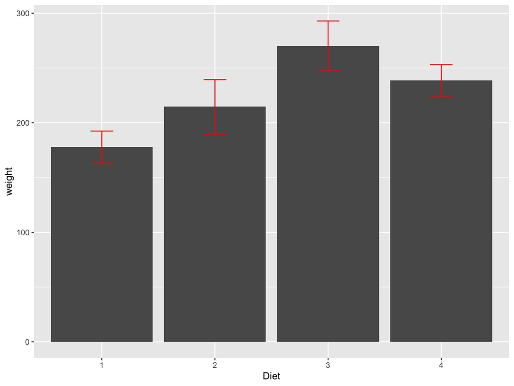

## Results 2.0

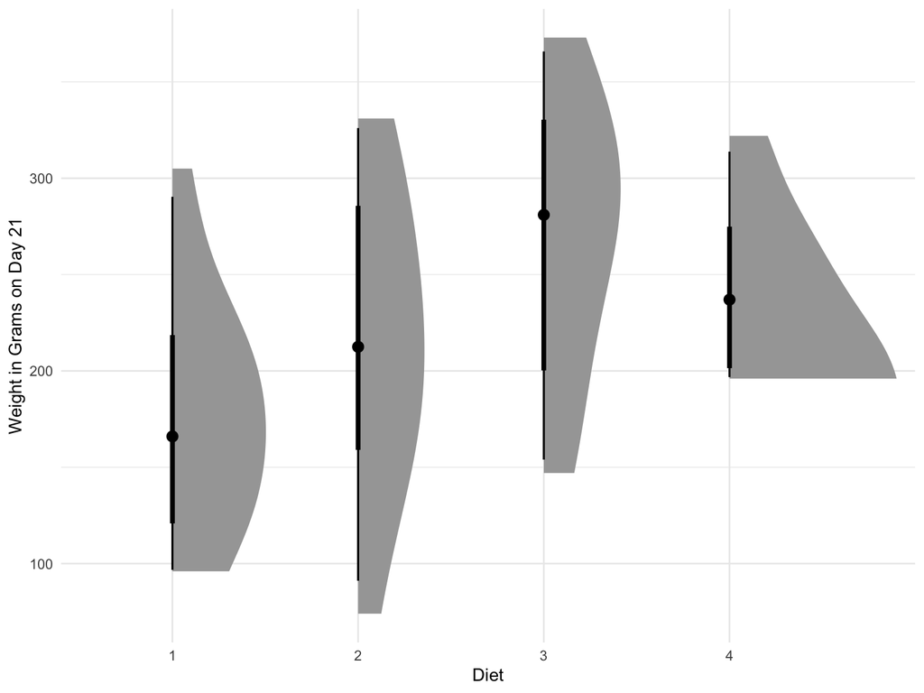